# Session 9: Advanced Tidyverse

R Programming Workbook

Author

R Programming Course

Published

April 29, 2026

**NoteLearning Objectives**

By the end of this session you will be able to:

1. Use the embrace operator `{ }` to write functions that accept column names
2. Apply the walrus operator `:=` for dynamic column naming
3. Use `.data` and `.env` pronouns for string-based column access
4. Create function factories that return specialized functions
5. Apply `reduce()` and `accumulate()` for sequential operations
6. Parse JSON data with jsonlite
7. Build and perform HTTP requests with httr2
8. Handle nested API responses with purrr
9. Implement error handling and rate limiting for API workflows

```r
library(dplyr)
library(purrr)
library(jsonlite)
library(tidyr)
library(ggplot2)

set.seed(42)
sales <- tibble(
  date = rep(seq(as.Date("2024-01-01"), as.Date("2024-12-31"), by = "day"), 3),
  region = rep(c("North", "South", "West"), each = 366),
  product = sample(c("Widget", "Gadget", "Doohickey"), 366 * 3, replace = TRUE),
  units = rpois(366 * 3, lambda = 50),
  revenue = round(runif(366 * 3, 10, 500), 2),
  returned = rbinom(366 * 3, 1, 0.05)
)
```

## Part 1: Tidy Evaluation

### The Problem: Column Names in Functions

When you write a function that calls dplyr verbs, you cannot pass column names like regular variables.

```r
# This does NOT work as expected
bad_mean <- function(data, col) {
  data |> summarize(result = mean(col))
}

# Try it -- you get an error or wrong result
# bad_mean(sales, revenue)
```

dplyr uses **data masking**: it treats bare names (like `revenue`) as columns, not as R variables. Inside your function, `col` is a symbol, not the column itself.

### The Embrace Operator {{ }}

Wrap function arguments in `{ }` to pass them through to dplyr:

```r
good_mean <- function(data, col) {
  data |> summarize(result = mean({{ col }}))
}

good_mean(sales, revenue)
```

```
# A tibble: 1 × 1
  result
   <dbl>
1   262.
```

```r
good_mean(sales, units)
```

```
# A tibble: 1 × 1
  result
   <dbl>
1   50.2
```

`{ }` tells dplyr: “evaluate this argument the way the caller intended.”

### Embrace in Multiple Contexts

```r
# Works in filter
filter_above <- function(data, col, threshold) {
  data |> filter({{ col }} > threshold)
}

sales |> filter_above(revenue, 400) |> head(5)
```

```
# A tibble: 5 × 6
  date       region product   units revenue returned
  <date>     <chr>  <chr>     <int>   <dbl>    <int>
1 2024-01-07 North  Gadget       46    466.        0
2 2024-01-09 North  Doohickey    47    443.        0
3 2024-01-15 North  Gadget       35    405.        0
4 2024-01-24 North  Widget       43    404.        0
5 2024-01-26 North  Doohickey    51    441.        0
```

```r
# Works in mutate
add_scaled <- function(data, col) {
  data |> mutate(scaled = ({{ col }} - mean({{ col }})) / sd({{ col }}))
}

sales |> add_scaled(revenue) |> select(revenue, scaled) |> head(5)
```

```
# A tibble: 5 × 2
  revenue scaled
    <dbl>  <dbl>
1    296.  0.244
2    337.  0.536
3    372.  0.789
4    339.  0.550
5     84  -1.27
```

```r
# Works in .by
grouped_summary <- function(data, group_col, value_col) {
  data |>
    summarize(
      mean_val = mean({{ value_col }}),
      n = n(),
      .by = {{ group_col }}
    )
}

sales |> grouped_summary(region, revenue)
```

```
# A tibble: 3 × 3
  region mean_val     n
  <chr>     <dbl> <int>
1 North      261.   366
2 South      263.   366
3 West       262.   366
```

### Dynamic Column Names with :=

Use the walrus operator `:=` with glue syntax for dynamic output names:

```r
named_summary <- function(data, group_col, value_col) {
  data |>
    summarize(
      "mean_{{ value_col }}" := mean({{ value_col }}),
      "sd_{{ value_col }}" := sd({{ value_col }}),
      .by = {{ group_col }}
    )
}

sales |> named_summary(region, revenue)
```

```
# A tibble: 3 × 3
  region mean_revenue sd_revenue
  <chr>         <dbl>      <dbl>
1 North          261.       143.
2 South          263.       135.
3 West           262.       142.
```

```r
sales |> named_summary(product, units)
```

```
# A tibble: 3 × 3
  product   mean_units sd_units
  <chr>          <dbl>    <dbl>
1 Widget          50.4     6.90
2 Gadget          50.1     7.20
3 Doohickey       50.1     7.33
```

### .data and .env Pronouns

When column names are strings (not bare symbols), use `.data[[ ]]`:

```r
col_name <- "revenue"
sales |> summarize(avg = mean(.data[[col_name]]), .by = region)
```

```
# A tibble: 3 × 2
  region   avg
  <chr>  <dbl>
1 North   261.
2 South   263.
3 West    262.
```

Use `.env` to refer to variables from the surrounding environment inside dplyr:

```r
threshold_val <- 300
sales |>
  filter(.data[["revenue"]] > .env[["threshold_val"]]) |>
  nrow()
```

```
[1] 468
```

**NoteBase R vs Tidyverse**

In base R, you access columns with `df[[col_name]]` where `col_name` is a string. No special syntax needed because base R does not use data masking. Tidy evaluation is the price you pay for the convenience of typing `revenue` instead of `df[["revenue"]]` everywhere.

### Your Turn: Exercise 1

Write a function `count_above` that takes a data frame, a column, and a threshold, and returns the number of rows where the column exceeds the threshold.

**Solution**

```r
count_above <- function(data, col, threshold) {
  data |>
    filter({{ col }} > threshold) |>
    nrow()
}

count_above(sales, revenue, 400)
```

```
[1] 220
```

**Solution**

```r
count_above(sales, units, 60)
```

```
[1] 82
```

### Your Turn: Exercise 2

Write a function `top_n_by_group` that takes a data frame, a grouping column, a value column, and n, then returns the top n rows by value within each group.

**Solution**

```r
top_n_by_group <- function(data, group_col, value_col, n = 3) {
  data |>
    slice_max({{ value_col }}, n = n, by = {{ group_col }})
}

sales |> top_n_by_group(region, revenue, n = 2) |> head(6)
```

```
# A tibble: 6 × 6
  date       region product units revenue returned
  <date>     <chr>  <chr>   <int>   <dbl>    <int>
1 2024-11-01 North  Widget     52    500.        0
2 2024-07-23 North  Widget     52    499.        0
3 2024-01-09 South  Gadget     42    500.        1
4 2024-09-26 South  Gadget     61    497.        0
5 2024-12-12 West   Widget     47    498.        0
6 2024-02-20 West   Gadget     62    498.        0
```

### Your Turn: Exercise 3

Write a function `quick_plot` that takes a data frame, x column, y column, and color column, then produces a scatter plot.

**Solution**

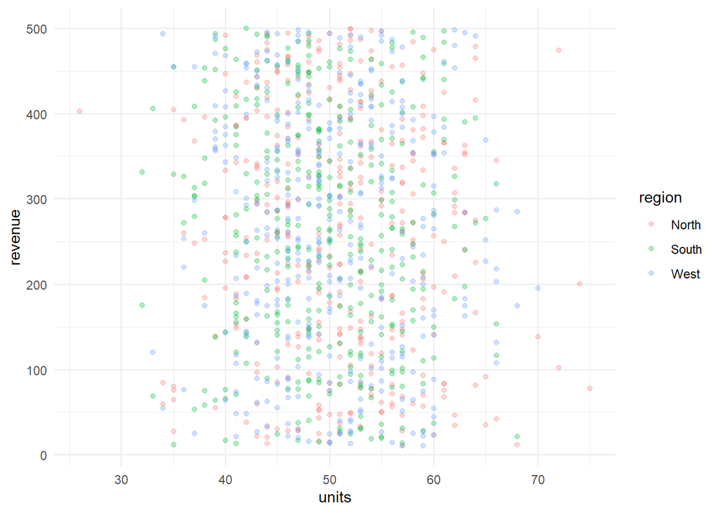

```r
quick_plot <- function(data, x_col, y_col, color_col) {
  ggplot(data, aes(x = {{ x_col }}, y = {{ y_col }}, color = {{ color_col }})) +
    geom_point(alpha = 0.3) +
    theme_minimal()
}

sales |> quick_plot(units, revenue, region)
```

**WarningCommon Mistake**

Forgetting `{ }` inside `aes()`:

```r
# WRONG -- plots nothing useful
quick_plot <- function(data, x_col, y_col) {
  ggplot(data, aes(x = x_col, y = y_col)) + geom_point()
}
```

ggplot2 also uses data masking. Always embrace column arguments inside `aes()`.

### Your Turn: Exercise 4

Write a function `summarize_string_col` that accepts a string column name (not a bare name) and computes the mean of that column.

**Solution**

```r
summarize_string_col <- function(data, col_string) {
  data |>
    summarize(mean_val = mean(.data[[col_string]], na.rm = TRUE))
}

summarize_string_col(sales, "revenue")
```

```
# A tibble: 1 × 1
  mean_val
     <dbl>
1     262.
```

**Solution**

```r
summarize_string_col(sales, "units")
```

```
# A tibble: 1 × 1
  mean_val
     <dbl>
1     50.2
```

**TipChallenge**

Write a function `multi_summarize` that accepts a data frame, a grouping column, and a character vector of column names. It should return the mean of each named column grouped by the grouping column. (Hint: use `across(all_of(...))`)

**Solution**

```r
multi_summarize <- function(data, group_col, col_names) {
  data |>
    summarize(
      across(all_of(col_names), \(x) mean(x, na.rm = TRUE)),
      .by = {{ group_col }}
    )
}

multi_summarize(sales, region, c("units", "revenue"))
```

```
# A tibble: 3 × 3
  region units revenue
  <chr>  <dbl>   <dbl>
1 North   51.0    261.
2 South   49.6    263.
3 West    50.0    262.
```

## Part 2: Functional Programming Patterns

### Function Factories

A function that returns a function:

```r
multiplier <- function(factor) {
  \(x) x * factor
}

double <- multiplier(2)
triple <- multiplier(3)

double(10)
```

```
[1] 20
```

```r
triple(10)
```

```
[1] 30
```

The returned function “remembers” the value of `factor` from when it was created. This is a closure.

### Practical Factory: Threshold Checker

```r
make_checker <- function(lower, upper) {
  \(x) x >= lower & x <= upper
}

valid_revenue <- make_checker(10, 500)
valid_units <- make_checker(0, 100)

sales |>
  filter(valid_revenue(revenue), valid_units(units)) |>
  nrow()
```

```
[1] 1098
```

### reduce() and accumulate()

`reduce()` applies a 2-argument function across a list from left to right:

```r
reduce(1:5, `+`)     # ((((1+2)+3)+4)+5) = 15
```

```
[1] 15
```

```r
reduce(1:5, `*`)     # 1*2*3*4*5 = 120
```

```
[1] 120
```

```r
# Merge multiple data frames
df1 <- tibble(id = 1:3, a = c("x", "y", "z"))
df2 <- tibble(id = 2:4, b = c(10, 20, 30))
df3 <- tibble(id = 1:4, c = c(TRUE, FALSE, TRUE, FALSE))

reduce(list(df1, df2, df3), inner_join, by = "id")
```

```
# A tibble: 2 × 4
     id a         b c
  <int> <chr> <dbl> <lgl>
1     2 y        10 FALSE
2     3 z        20 TRUE
```

`accumulate()` returns all intermediate results:

```r
# Running total
transactions <- c(100, -30, 50, -10, 80)
accumulate(transactions, `+`)
```

```
[1] 100  70 120 110 190
```

### Your Turn: Exercise 5

Create a function factory `make_normalizer` that takes a vector and returns a function that normalizes new values to the 0-1 range using the original vector’s min and max.

**Solution**

```r
make_normalizer <- function(reference) {
  rng <- range(reference, na.rm = TRUE)
  \(x) (x - rng[1]) / (rng[2] - rng[1])
}

norm_revenue <- make_normalizer(sales$revenue)
norm_revenue(c(100, 250, 500))
```

```
[1] 0.1826878 0.4892795 1.0002657
```

### Your Turn: Exercise 6

Use `reduce()` to find the intersection of these three vectors:

```r
v1 <- c(1, 2, 3, 4, 5)
v2 <- c(2, 4, 6, 8)
v3 <- c(3, 4, 5, 6)
```

**Solution**

```r
reduce(list(v1, v2, v3), intersect)
```

```
[1] 4
```

### Your Turn: Exercise 7

Use `accumulate()` to compute a running product of `c(2, 3, 4, 5)`.

**Solution**

```r
accumulate(c(2, 3, 4, 5), `*`)
```

```
[1]   2   6  24 120
```

**WarningCommon Mistake**

Forgetting that `reduce()` needs a binary function (exactly 2 arguments):

```r
# WRONG
reduce(1:5, sqrt)  # sqrt takes 1 argument, reduce needs 2
```

The function passed to `reduce()` must take `(accumulated, next_element)`.